# INTRODUCTION TO DATA VISUALIZATION WITH GGPLOT2

Load **gpplot2** package:

```r
library(ggplot2)
```

### 1.1 Data visualization and Data Science

Data visualization is an essential skill for data scientists. It combines statistics in meaningful and appropriate ways. On one hand, data visualization is a form of graphic data analysis, emphasizing accurate representation and interpretation of data. On the other hand, data visualization relies on good design choices, not only to make the plots attractive, but also to aid both the understanding and communication of the results. On top of that, there is an element of creativity, since at its heart, data visualization is a form of visual communication.

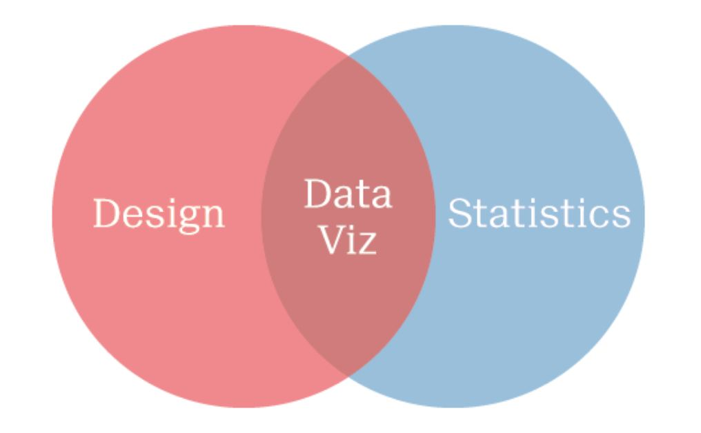

It is important to understand the distinction between *exploratory* and *explanatory* visualizations.

- Exploratory visualizations: easily-generated, data-heavy and intended for a small specialist audience - the primary purpose is graphical data analysis.
- Explanatory visualizations: labor-intensive, data-specific and intended for broader audience, like in publications or presentations - they are part of the communication process.

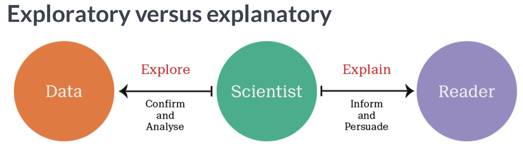

For example, examine the **mammals** dataset from **MASS** package. This dataset contains the average brain and body weights of 62 land mammals.

```r
library(MASS)
MASS::mammals
```

```
##                               body   brain
## Arctic fox                   3.385   44.50
## Owl monkey                   0.480   15.50
## Mountain beaver              1.350    8.10
## Cow                        465.000  423.00
## Grey wolf                   36.330  119.50
## Goat                        27.660  115.00
## Roe deer                    14.830   98.20
## Guinea pig                   1.040    5.50
## Verbet                       4.190   58.00
## Chinchilla                   0.425    6.40
## Ground squirrel              0.101    4.00
## Arctic ground squirrel       0.920    5.70
## African giant pouched rat    1.000    6.60
## Lesser short-tailed shrew    0.005    0.14
## Star-nosed mole              0.060    1.00
## Nine-banded armadillo        3.500   10.80
## Tree hyrax                   2.000   12.30
## N.A. opossum                 1.700    6.30
## Asian elephant            2547.000 4603.00
## Big brown bat                0.023    0.30
## Donkey                     187.100  419.00
## Horse                      521.000  655.00
## European hedgehog            0.785    3.50
## Patas monkey                10.000  115.00
## Cat                          3.300   25.60
## Galago                       0.200    5.00
## Genet                        1.410   17.50
## Giraffe                    529.000  680.00
## Gorilla                    207.000  406.00
## Grey seal                   85.000  325.00
## Rock hyrax-a                 0.750   12.30
## Human                       62.000 1320.00
## African elephant          6654.000 5712.00
## Water opossum                3.500    3.90
## Rhesus monkey                6.800  179.00
## Kangaroo                    35.000   56.00
## Yellow-bellied marmot        4.050   17.00
## Golden hamster               0.120    1.00
## Mouse                        0.023    0.40
```

[output cut: 8 more lines]

```
## Desert hedgehog              0.550    2.40
## Giant armadillo             60.000   81.00
## Rock hyrax-b                 3.600   21.00
## Raccoon                      4.288   39.20
## Rat                          0.280    1.90
## E. American mole             0.075    1.20
## Mole rat                     0.122    3.00
## Musk shrew                   0.048    0.33
## Pig                        192.000  180.00
## Echidna                      3.000   25.00
## Brazilian tapir            160.000  169.00
## Tenrec                       0.900    2.60
## Phalanger                    1.620   11.40
## Tree shrew                   0.104    2.50
## Red fox                      4.235   50.40
```

To understand the relationship here, the most obvious first step is to make a scatter plot.

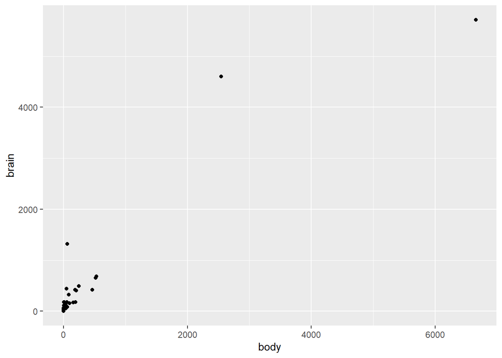

```r
ggplot(mammals, aes(body, brain)) +
  geom_point()
```

Two mammals, the African and Asian Elephants have both very large brain and body weights, leading to a positive skew on both axes. Applying here a linear model is a poor choice since a few extreme values have a large influence.

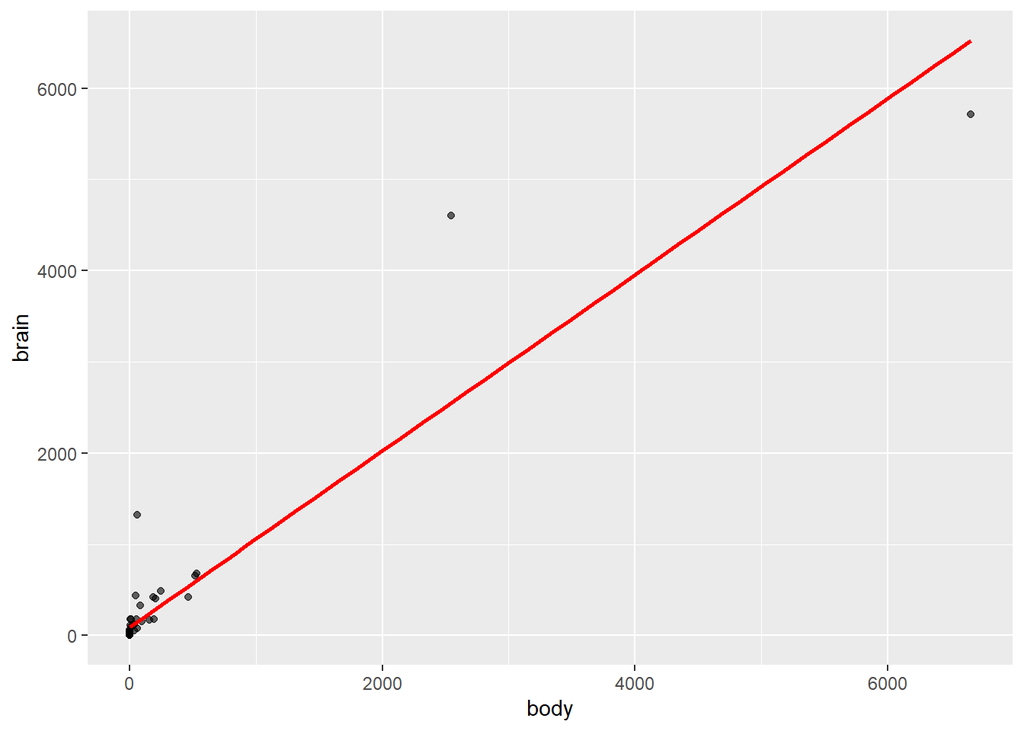

```r
ggplot(mammals, aes(body, brain)) +
  geom_point(alpha = 0.6) +
  stat_smooth(method = "lm",
              color = "red",
              se = FALSE)
```

A log transformation of both variables allows for a better fit.

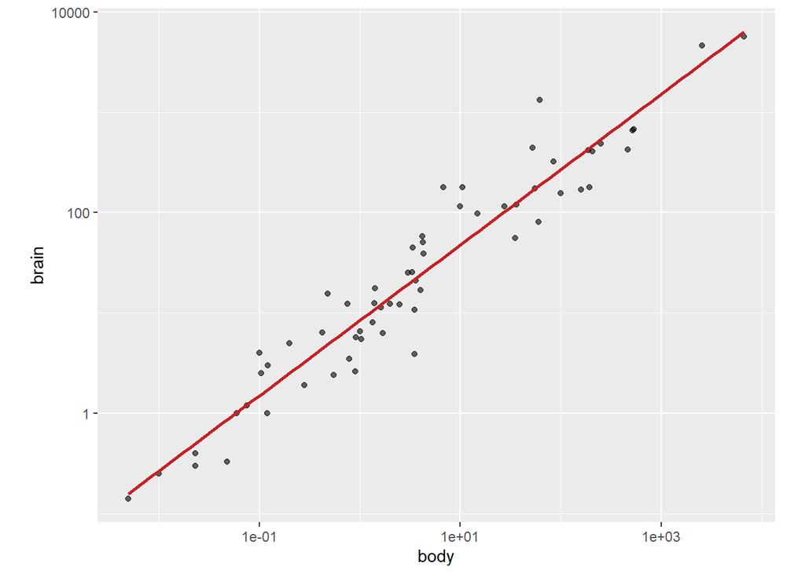

```r
ggplot(mammals, aes(body, brain)) +
  geom_point(alpha = 0.6) +
  coord_fixed() +
  scale_x_log10() +
  scale_y_log10() +
  stat_smooth(method = "lm",
              color = "#C42126",
              se = FALSE,
              size = 1)
```

Although we began with a rough exploratory plot, that informed us about our data and lead us to a meaningful result. In the end, we would probably want to a cleaned-up explanatory plot.

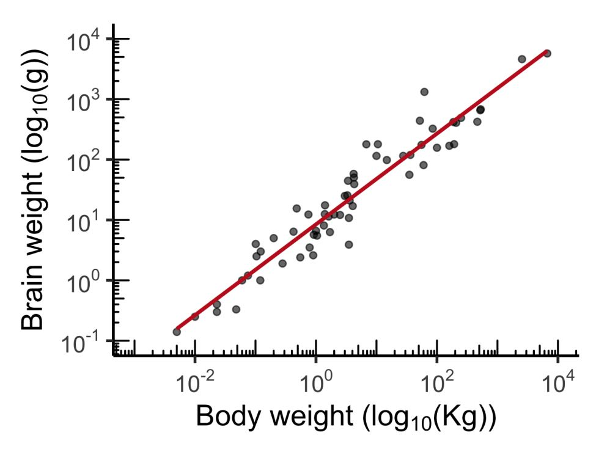

**Ancombe’s quartet**

Ancombe’s quartet is the classic example from Francis Anscombe, first published in 1973. It comprises four data sets that have nearly identical simple descriptive statistics, yet have very different distributions and appear very different when graphed. If we rely solely on the numerical output without plotting the data, we could have missed distinct and interesting underlying trends.

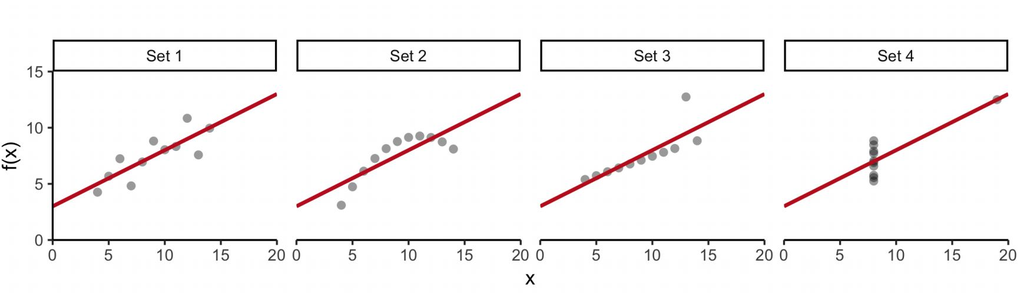

Data vizualization is rooted in statistics and graphical data analysis, but it is also a creative process that involves some amount of trial and error.

### 1.2 The grammar of graphics

The first step in thinking creatively about data visualization is to appreciate that graphics are built upon an underlying grammar. Let’s consider on of the most well-known sentences in English.

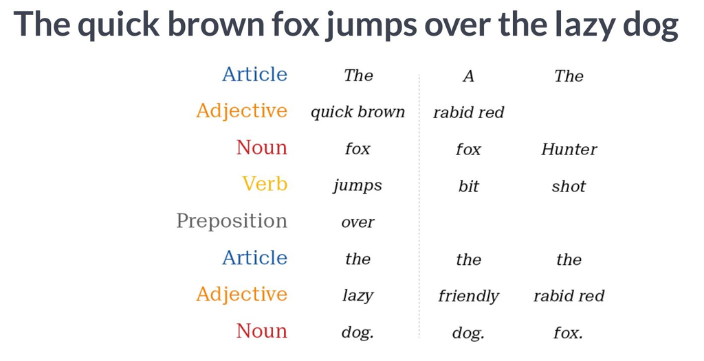

Every word in the sentence has a clear grammatical definition and when we write text, we take great care to choose the grammatical elements so that we communicate a very specific message. If we changed any of the grammatical elements of this sentence, it will change the meaning.

The same concept holds true for data visualization - graphics are built on underlying grammar. There are two principles in the grammar of graphics:

- Graphics are made up of distinct layers of grammatical elements.
- Meaningful plots are built around appropriate aesthetic mappings.

The layers are like the adjectives and nouns, and the aesthetic mappings are like the grammatical rules for how to assemble the vocabulary.

There are seven grammatical elements:

- *data*: the dataset being plotted.
- *aesthetics*: the scales onto which we *map* data.
- *geometries (geom)*: the visual elements used for data, the actual shape data will take in the plot.
- *themes*: all non-data ink.
- *statistics (stat)*: representations of data to aid understanding.
- *coordinates*: the space on which data will be plotted.
- *facets*: plotting small multiples.

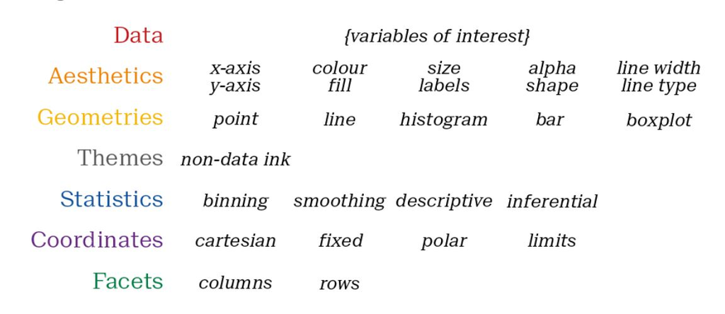

Data, aesthetics and geometries are essential grammatical elements. The rest are optional layers.